# Untitled

```r
# install.packages(c('ggplot2', 'tidyr', 'ROCR', 'broom', 'readr',
#                    'dplyr', 'DBI', 'RSQLite',
#                    'tibble', 'lattice', 'modelr', 'stringr', 'MASS',
#                    'car',
#                    'caret', 'gridExtra', 'lsmeans', 'lme4'))

library(ggplot2)
#library(plotly)
library(dplyr)
library(tibble)
library(readr) # str_c, str_sub
library(tidyr)
library(broom) # tidy(model)
library(stringr)
library(modelr) # add_residuals
library(lattice) # splom
library(gridExtra) # grid.arrange
library(MASS) # for lm.ridge and boxcox, also fucks up dplyrs select
library(car) # for vif
library(lsmeans) # for adjusted means
library(caret) # confusionMatrix
library(ROCR)
library(lme4)
```

- derive associatiations
- use to esdtablish a graph
- then look for communities in that graph? / clusters?
  - notice the betweenness centrality based community detection would work well bc we can remove the people who are overlapping and be left w the communities
  - think of a grocery store, various cuisines and then people who eat lots of different cuisines are screwing up your results
- knitting across different languages:
  - (http://rmarkdown.rstudio.com/authoring_knitr_engines.html?utm_content=buffer5cc17&utm_medium=social&utm_source=twitter.com&utm_campaign=buffer)
- data: https://blogs.technet.microsoft.com/dataplatforminsider/2016/06/09/wideworldimporters-the-new-sql-server-sample-database/
- ex: https://github.com/Microsoft/sql-server-samples/blob/master/samples/databases/wide-world-importers/sample-scripts/operational-analytics/DemonstrateOperationalAnalyticsPerformance.sql

# Goals

- unsupervised:
  - identify associations between products
  - rep products as a graph
  - get an idea for the similar products by grouping them
- supervised ideas:
  - forecast sales
  - forecast whether sales persons sales are going to increase or decrease from 1 time period to the next (yearly)
  - recommend products based on associations
  - predict when we’ll be undersupplied
- use:
  - cross reference w Customer Categories

```r
library(RODBC)
#db <- odbcDriverConnect('driver={SQL Server};server=localhost;database=WideWorldImporters;trusted_connection=true')
drv <- odbcDriverConnect('driver={SQL Server};server=THE-ENTERPRISE\\SQLEXPRESS;database=WideWorldImporters;trusted_connection=true')
sqlQuery(drv, 'select * from information_schema.tables')
```

```
##         TABLE_CATALOG TABLE_SCHEMA                        TABLE_NAME
## 1  WideWorldImporters    Warehouse                            Colors
## 2  WideWorldImporters    Warehouse                    Colors_Archive
## 3  WideWorldImporters        Sales                        OrderLines
## 4  WideWorldImporters    Warehouse                      PackageTypes
## 5  WideWorldImporters    Warehouse              PackageTypes_Archive
## 6  WideWorldImporters    Warehouse                       StockGroups
## 7  WideWorldImporters    Warehouse              StockItemStockGroups
## 8  WideWorldImporters    Warehouse               StockGroups_Archive
## 9  WideWorldImporters  Application                    StateProvinces
## 10 WideWorldImporters        Sales              CustomerTransactions
## 11 WideWorldImporters  Application            StateProvinces_Archive
## 12 WideWorldImporters  Application                            Cities
## 13 WideWorldImporters  Application                    Cities_Archive
## 14 WideWorldImporters  Application                  SystemParameters
```

[output cut: 101 more lines]

## little exploration in sql

- lets decide what we want to use as features and get a better look into our data

```r
sqlQuery(drv, 'select top 10 * from Sales.OrderLines;') # products
```

```
##    OrderLineID OrderID StockItemID
## 1            1      45         164
## 2            2       1          67
## 3            3       2          50
## 4            4      46          89
## 5            5      46         171
## 6            6       2          10
## 7            7      47         167
## 8            8      47         219
## 9            9       3         114
## 10          10      47          72
##                                                Description PackageTypeID
## 1                       32 mm Double sided bubble wrap 50m             7
## 2                 Ride on toy sedan car (Black) 1/12 scale             7
## 3  Developer joke mug - old C developers never die (White)             7
```

[output cut: 29 more lines]

```r
sqlQuery(drv, 'select top 10 * from Sales.Orders;') # orders
```

```
##    OrderID CustomerID SalespersonPersonID PickedByPersonID ContactPersonID
## 1        1        832                   2               NA            3032
## 2        2        803                   8               NA            3003
## 3        3        105                   7               NA            1209
## 4        4         57                  16                3            1113
## 5        5        905                   3               NA            3105
## 6        6        976                  13                3            3176
## 7        7        575                   8               NA            2349
## 8        8        964                   7               NA            3164
## 9        9         77                   7               NA            1153
## 10      10        191                  20               NA            1381
##    BackorderOrderID  OrderDate ExpectedDeliveryDate
## 1                45 2013-01-01           2013-01-02
## 2                46 2013-01-01           2013-01-02
## 3                47 2013-01-01           2013-01-02
```

[output cut: 40 more lines]

```r
sqlQuery(drv, 'select top 10 * from [Application].[People];', rows_at_time = 1, max=10) # info on sales people not helpful
```

```
##    PersonID             FullName        PreferredName
## 1         1 Data Conversion Only Data Conversion Only
## 2         2       Kayla Woodcock                Kayla
## 3         3        Hudson Onslow               Hudson
## 4         4        Isabella Rupp             Isabella
## 5         5          Eva Muirden                  Eva
## 6         6        Sophia Hinton               Sophia
## 7         7            Amy Trefl                  Amy
## 8         8       Anthony Grosse              Anthony
## 9         9       Alica Fatnowna                Alica
## 10       10     Stella Rosenhain               Stella
##                                   SearchName IsPermittedToLogon
## 1  Data Conversion Only Data Conversion Only                  0
## 2                       Kayla Kayla Woodcock                  1
## 3                       Hudson Hudson Onslow                  1
```

[output cut: 95 more lines]

```r
# cant allocate enough memoria
# couldnt allocate enough memory in R
sqlQuery(drv, 'select min(OrderDate) from Sales.Orders;')
```

```
##
## 1 2013-01-01
```

```r
sqlQuery(drv, 'select max(OrderDate) from Sales.Orders;')
```

```
##
## 1 2016-05-31
```

```r
sqlQuery(drv, 'select count(*)  from Sales.OrderLines;')
```

```
##
## 1 231412
```

```r
sqlQuery(drv, 'select count(*) from Sales.Orders;')
```

```
##
## 1 73595
```

```r
# lets look for more features
sqlQuery(drv, 'select top 10 * from Sales.BuyingGroups;') # not helpful
```

```
##   BuyingGroupID BuyingGroupName LastEditedBy                   ValidFrom
## 1             1   Tailspin Toys            1 2013-01-01 00:00:00.0000000
## 2             2    Wingtip Toys            1 2013-01-01 00:00:00.0000000
##                       ValidTo
## 1 9999-12-31 23:59:59.9999999
## 2 9999-12-31 23:59:59.9999999
```

```r
# could look into more, look for an effect
sqlQuery(drv, 'select top 10 * from Sales.SpecialDeals;') # not helpful
```

```
##   SpecialDealID StockItemID CustomerID BuyingGroupID CustomerCategoryID
## 1             1          NA         NA             2                 NA
## 2             2          NA         NA             1                 NA
##   StockGroupID          DealDescription  StartDate    EndDate
## 1            7  10% 1st qtr USB Wingtip 2016-01-01 2016-03-31
## 2            7 15% 2nd qtr USB Tailspin 2016-04-01 2016-06-30
##   DiscountAmount DiscountPercentage UnitPrice LastEditedBy
## 1             NA                 10        NA            2
## 2             NA                 15        NA            2
##                LastEditedWhen
## 1 2015-12-31 16:00:00.0000000
## 2 2015-12-31 16:00:00.0000000
```

```r
# deals could have been confounding results on us
sqlQuery(drv, 'select top 10 * from Sales.Customers;', rows_at_time = 1, max=10) # helpful w below
```

```
##    CustomerID                       CustomerName BillToCustomerID
## 1           1        Tailspin Toys (Head Office)                1
## 2           2      Tailspin Toys (Sylvanite, MT)                1
## 3           3 Tailspin Toys (Peeples Valley, AZ)                1
## 4           4 Tailspin Toys (Medicine Lodge, KS)                1
## 5           5        Tailspin Toys (Gasport, NY)                1
## 6           6         Tailspin Toys (Jessie, ND)                1
## 7           7     Tailspin Toys (Frankewing, TN)                1
## 8           8        Tailspin Toys (Bow Mar, CO)                1
## 9           9        Tailspin Toys (Netcong, NJ)                1
## 10         10      Tailspin Toys (Wimbledon, ND)                1
##    CustomerCategoryID BuyingGroupID PrimaryContactPersonID
## 1                   3             1                   1001
## 2                   3             1                   1003
## 3                   3             1                   1005
```

[output cut: 106 more lines]

```r
sqlQuery(drv, 'select top 10 * from Sales.CustomerCategories;') # helpful
```

```
##   CustomerCategoryID CustomerCategoryName LastEditedBy
## 1                  1                Agent            1
## 2                  2           Wholesaler            1
## 3                  3         Novelty Shop            1
## 4                  4          Supermarket            1
## 5                  5       Computer Store            1
## 6                  6           Gift Store            1
## 7                  7            Corporate            1
## 8                  8     General Retailer            9
##                     ValidFrom                     ValidTo
## 1 2013-01-01 00:00:00.0000000 9999-12-31 23:59:59.9999999
## 2 2013-01-01 00:00:00.0000000 9999-12-31 23:59:59.9999999
## 3 2013-01-01 00:00:00.0000000 9999-12-31 23:59:59.9999999
## 4 2013-01-01 00:00:00.0000000 9999-12-31 23:59:59.9999999
## 5 2013-01-01 00:00:00.0000000 9999-12-31 23:59:59.9999999
## 6 2013-01-01 00:00:00.0000000 9999-12-31 23:59:59.9999999
## 7 2013-01-01 00:00:00.0000000 9999-12-31 23:59:59.9999999
## 8 2014-01-01 16:15:00.0000000 9999-12-31 23:59:59.9999999
```

```r
sqlQuery(drv, 'select count(*) from Sales.CustomerCategories_Archive;') # not helpful
```

```
##
## 1 1
```

```r
# get geographic data
sqlQuery(drv, 'select top 10
                    t3.CustomerName, t6.CityName, t7.StateProvinceName,
                    t8.CountryName
                from Sales.Customers as t3
                    inner join Application.Cities as t6
                        on t3.DeliveryCityID = t6.CityID
                    inner join Application.StateProvinces as t7
                        on t7.StateProvinceID = t6.StateProvinceID
                    inner join Application.Countries as t8
                        on t7.CountryID = t8.CountryID;')
```

```
##                       CustomerName     CityName StateProvinceName
## 1     Tailspin Toys (Antonito, CO)     Antonito          Colorado
## 2     Tailspin Toys (Bethania, NC)     Bethania    North Carolina
## 3  Wingtip Toys (Bethel Acres, OK) Bethel Acres          Oklahoma
## 4    Tailspin Toys (Big Moose, NY)    Big Moose          New York
## 5              Aishwarya Dantuluri        Biggs        California
## 6                    Nadir Seddigh       Biorka            Alaska
## 7      Tailspin Toys (Antares, AZ)      Antares           Arizona
## 8       Tailspin Toys (Biscay, MN)       Biscay         Minnesota
## 9    Wingtip Toys (Black Lick, PA)   Black Lick      Pennsylvania
## 10  Tailspin Toys (Annamoriah, WV)   Annamoriah     West Virginia
##      CountryName
## 1  United States
## 2  United States
## 3  United States
## 4  United States
## 5  United States
## 6  United States
## 7  United States
## 8  United States
## 9  United States
## 10 United States
```

## lets try to identify what drives the most revenue per order, while controlling for as much bias as possible

- confounding variables are a huge concern

### train test split

- should always do so
- train test eval set is even better
- **if we were making a model for prediction more than inference we should have kept a hold out set into the future (last few months)**

```r
train <- tbl_df(sqlQuery(drv, 'select * from feature_table_train;'))
```

### EDA (R is the best for EDA)

- see chapter 7 of R4DS by hadley wickham: http://r4ds.had.co.nz/exploratory-data-analysis.html

#### dependent variable

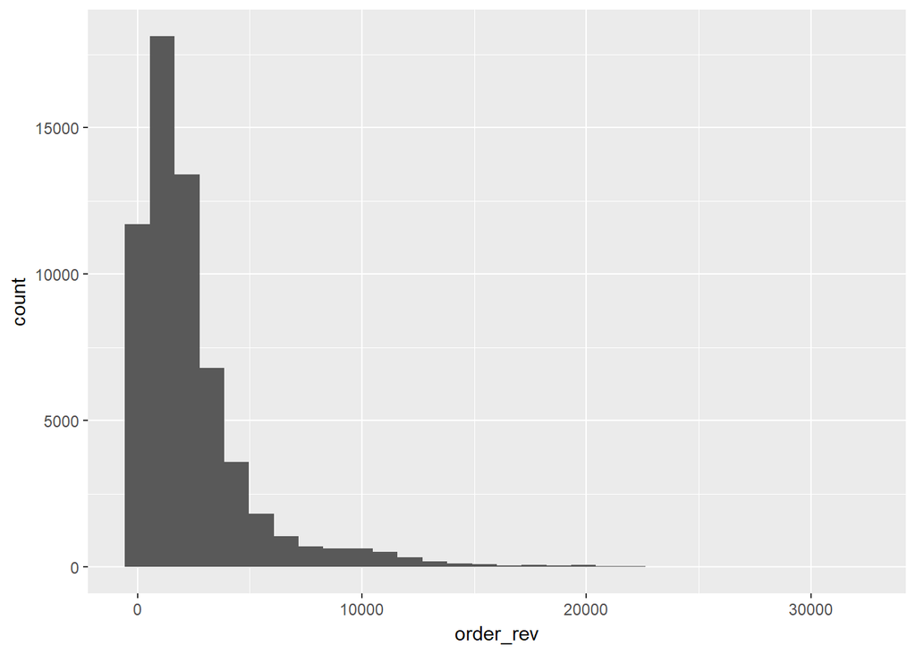

```r
ggplot(train, aes(order_rev)) +
  geom_histogram()
```

- to make this easier to work with lets log this
  - extreme outliers will make it harder to interpret our results visually
  - and worsen our results from linea regression

```r
print(min(train$order_rev))
```

```
## [1] 4.8
```

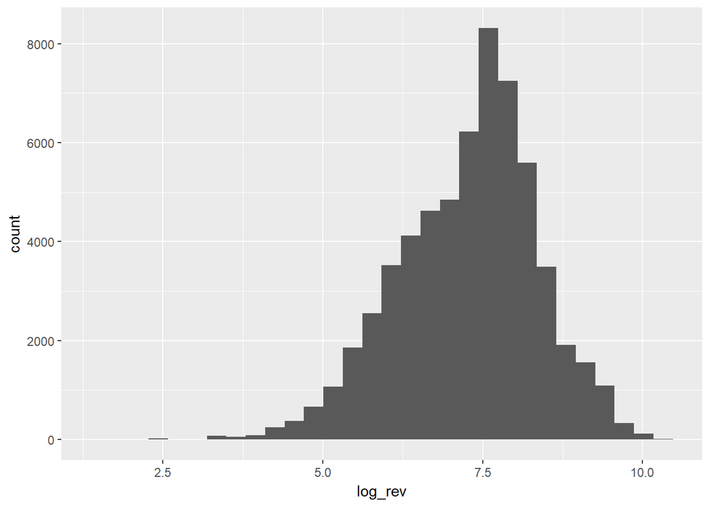

```r
train <- train %>% mutate(log_rev = log(order_rev))

ggplot(train, aes(log_rev)) + geom_histogram()
```

#### how much variability do we have between months and years?

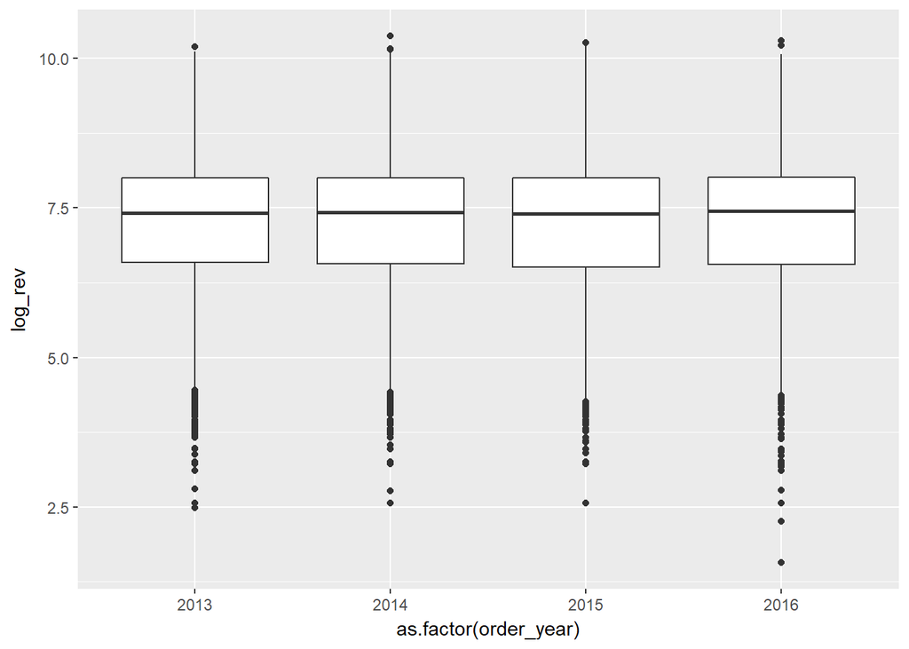

```r
ggplot(train, aes(as.factor(order_year), log_rev)) +
  geom_boxplot()
```

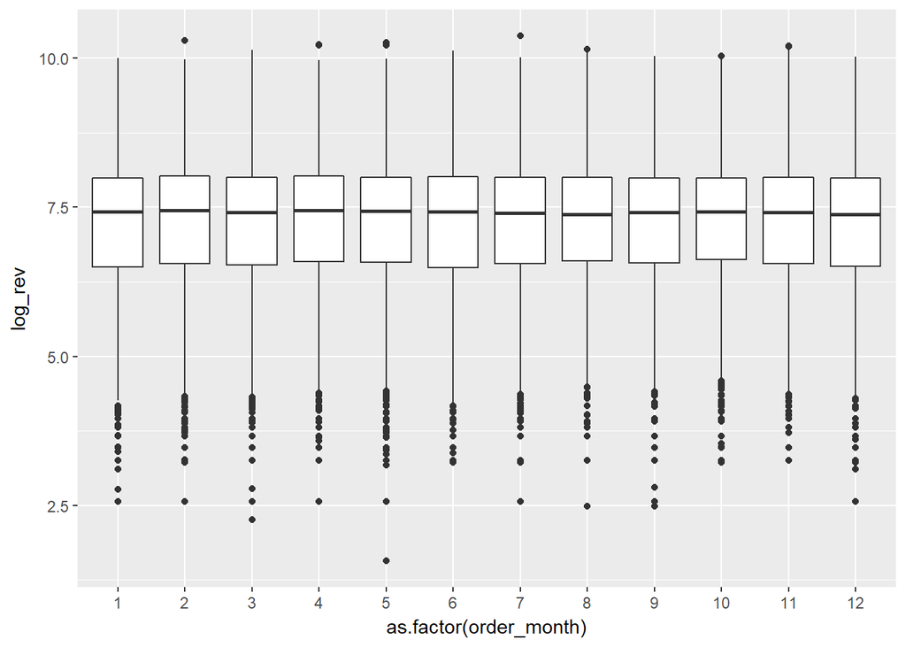

```r
ggplot(train, aes(as.factor(order_month), log_rev)) +
  geom_boxplot()
```

#### what if we isolate to individual sales persons and customer categories

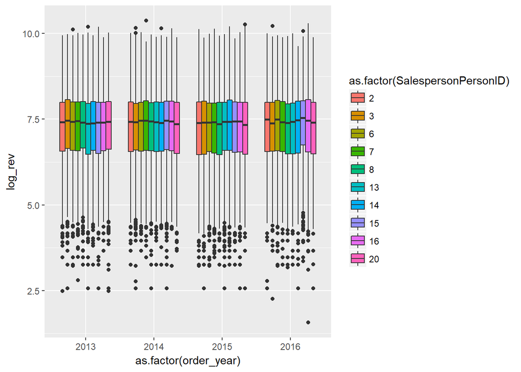

```r
ggplot(train, aes(as.factor(order_year), log_rev, fill=as.factor(SalespersonPersonID))) +
  geom_boxplot()
```

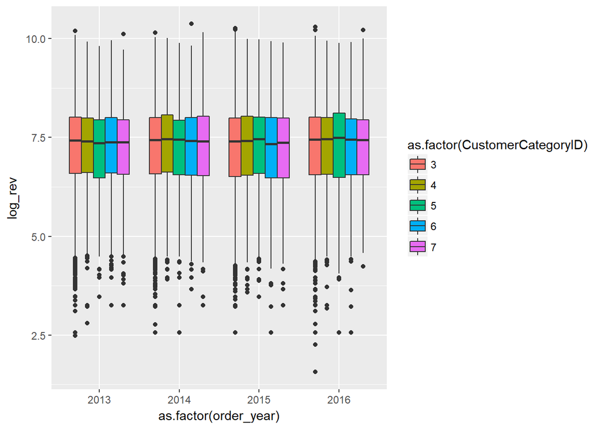

```r
ggplot(train, aes(as.factor(order_year), log_rev, fill=as.factor(CustomerCategoryID))) +
  geom_boxplot()
```

- more variability, than before as we would expect

#### do we have enough data to narrow down into subcategries?

- if not we’ll end up overfitting and our insights wont be valid

```r
train %>% group_by(order_month, SalespersonPersonID) %>% count() %>% arrange(n)
```

```
## # A tibble: 120 x 3
## # Groups:   order_month, SalespersonPersonID [120]
##    order_month SalespersonPersonID     n
##          <int>               <int> <int>
##  1          11                   7   374
##  2           8                  14   376
##  3           8                   8   378
##  4           8                   6   381
##  5           9                   3   383
##  6           9                  14   387
##  7          11                  13   387
##  8           8                   3   397
##  9           8                   7   398
## 10          11                   8   402
## # ... with 110 more rows
```

```r
train %>% group_by(order_month, CustomerCategoryID) %>% count()  %>% arrange(n)
```

```
## # A tibble: 60 x 3
## # Groups:   order_month, CustomerCategoryID [60]
##    order_month CustomerCategoryID     n
##          <int>              <int> <int>
##  1           8                  5   250
##  2           8                  7   272
##  3          11                  5   273
##  4           6                  7   275
##  5           8                  6   275
##  6           9                  7   283
##  7           9                  5   289
##  8           6                  5   297
##  9          11                  7   297
## 10           9                  6   301
## # ... with 50 more rows
```

```r
train %>% group_by(order_month, StateProvinceID) %>% count()  %>% arrange(n)
```

```
## # A tibble: 588 x 3
## # Groups:   order_month, StateProvinceID [588]
##    order_month StateProvinceID     n
##          <int>           <int> <int>
##  1          12              12     4
##  2          11              12     6
##  3           5              12     7
##  4           6              12     9
##  5           2              12    10
##  6           3              12    10
##  7           9              12    10
##  8           4              12    11
##  9           7              12    11
## 10           8              12    11
## # ... with 578 more rows
```

- state/province is more concentrated than the others
  - if we were to include the interaction w this and each month we’d want to filter out the less common states

#### lets look at the other on a weekly level

```r
train %>% group_by(order_wk, SalespersonPersonID) %>% count() %>% arrange(n)
```

```
## # A tibble: 530 x 3
## # Groups:   order_wk, SalespersonPersonID [530]
##    order_wk SalespersonPersonID     n
##       <int>               <int> <int>
##  1       53                   7    51
##  2       53                  13    52
##  3       53                   6    58
##  4        1                   3    60
##  5       53                  14    61
##  6       53                  15    61
##  7        1                  16    62
##  8       53                   8    62
##  9       53                   3    63
## 10        1                   7    64
## # ... with 520 more rows
```

```r
train %>% group_by(order_wk, CustomerCategoryID) %>% count()  %>% arrange(n)
```

```
## # A tibble: 265 x 3
## # Groups:   order_wk, CustomerCategoryID [265]
##    order_wk CustomerCategoryID     n
##       <int>              <int> <int>
##  1       53                  5    38
##  2       53                  6    39
##  3       53                  7    45
##  4        1                  7    47
##  5       34                  5    47
##  6       38                  7    49
##  7       31                  7    53
##  8       25                  5    54
##  9       38                  5    54
## 10       32                  6    55
## # ... with 255 more rows
```

not bad, but still quite small

### linear model

```r
lm1 <- lm(log_rev ~ as.factor(order_month) + as.factor(order_year) + as.factor(order_wk) +
           as.factor(SalespersonPersonID) + as.factor(CustomerCategoryID) + as.factor(StateProvinceID),
         data=train)

anova(lm1)
```

```
## Analysis of Variance Table
##
## Response: log_rev
##                                   Df Sum Sq Mean Sq F value    Pr(>F)
## as.factor(order_month)            11     18  1.6036  1.3707 0.1790238
## as.factor(order_year)              3     14  4.5137  3.8579 0.0089995 **
## as.factor(order_wk)               52    112  2.1575  1.8441 0.0002051 ***
## as.factor(SalespersonPersonID)     9     10  1.1018  0.9417 0.4870483
## as.factor(CustomerCategoryID)      4      3  0.8070  0.6898 0.5989282
## as.factor(StateProvinceID)        48     44  0.9190  0.7855 0.8571215
## Residuals                      59872  70048  1.1700
## ---
## Signif. codes:  0 '***' 0.001 '**' 0.01 '*' 0.05 '.' 0.1 ' ' 1
```

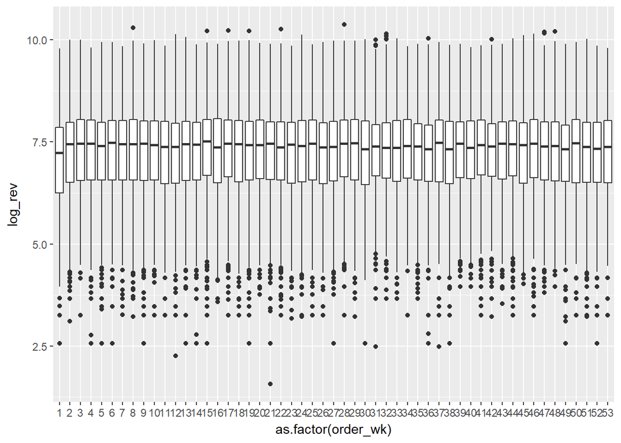

```r
ggplot(train, aes(as.factor(order_wk), log_rev)) + geom_boxplot()
```

lets look a little deeper for seasonal trends for each feature

```r
lm1 <- lm(log_rev ~ as.factor(order_year) *  as.factor(SalespersonPersonID) +
            as.factor(order_month) * as.factor(SalespersonPersonID) +
            as.factor(order_year) *  as.factor(CustomerCategoryID) +
            as.factor(order_month) * as.factor(CustomerCategoryID) +
            as.factor(order_wk) +
          + as.factor(StateProvinceID),
         data=train)

anova(lm1)
```

```
## Analysis of Variance Table
##
## Response: log_rev
##                                                          Df Sum Sq Mean Sq
## as.factor(order_year)                                     3     13  4.3406
## as.factor(SalespersonPersonID)                            9     10  1.1092
## as.factor(order_month)                                   11     18  1.6656
## as.factor(CustomerCategoryID)                             4      3  0.8661
## as.factor(order_wk)                                      52    112  2.1486
## as.factor(StateProvinceID)                               48     44  0.9190
## as.factor(order_year):as.factor(SalespersonPersonID)     27     29  1.0621
## as.factor(SalespersonPersonID):as.factor(order_month)    99    123  1.2376
## as.factor(order_year):as.factor(CustomerCategoryID)      12     11  0.8942
## as.factor(order_month):as.factor(CustomerCategoryID)     44     61  1.3901
## Residuals                                             59690  69825  1.1698
##                                                       F value    Pr(>F)
## as.factor(order_year)                                  3.7105 0.0110403
## as.factor(SalespersonPersonID)                         0.9482 0.4813681
## as.factor(order_month)                                 1.4238 0.1541886
## as.factor(CustomerCategoryID)                          0.7404 0.5642928
## as.factor(order_wk)                                    1.8367 0.0002257
## as.factor(StateProvinceID)                             0.7856 0.8569728
## as.factor(order_year):as.factor(SalespersonPersonID)   0.9080 0.6016041
## as.factor(SalespersonPersonID):as.factor(order_month)  1.0580 0.3274598
## as.factor(order_year):as.factor(CustomerCategoryID)    0.7644 0.6880553
## as.factor(order_month):as.factor(CustomerCategoryID)   1.1883 0.1833205
## Residuals
##
## as.factor(order_year)                                 *
## as.factor(SalespersonPersonID)
## as.factor(order_month)
## as.factor(CustomerCategoryID)
## as.factor(order_wk)                                   ***
## as.factor(StateProvinceID)
## as.factor(order_year):as.factor(SalespersonPersonID)
## as.factor(SalespersonPersonID):as.factor(order_month)
## as.factor(order_year):as.factor(CustomerCategoryID)
## as.factor(order_month):as.factor(CustomerCategoryID)
## Residuals
## ---
## Signif. codes:  0 '***' 0.001 '**' 0.01 '*' 0.05 '.' 0.1 ' ' 1
```

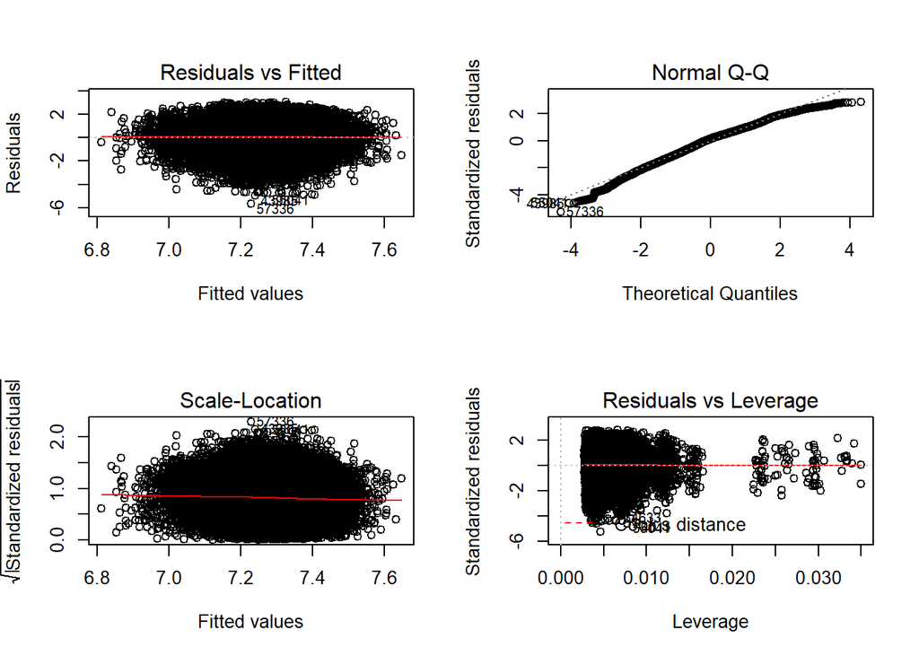

```r
par(mfrow=c(2,2))
plot(lm1)
```

#### still very little effects from our features

## potentially too many outliers to interpret effects with our features, we can fix this by binarizing our dependent

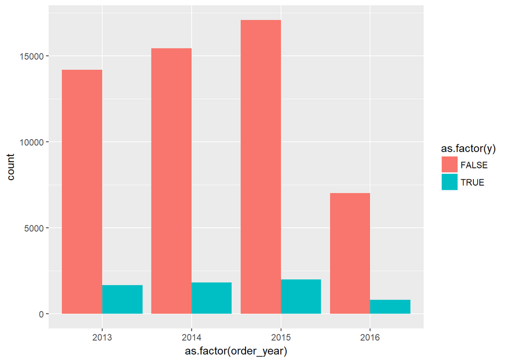

```r
train <- train %>% mutate(y = order_rev > 5000)

ggplot(train, aes(as.factor(order_year), fill=as.factor(y))) +
  geom_bar(position='dodge')
```

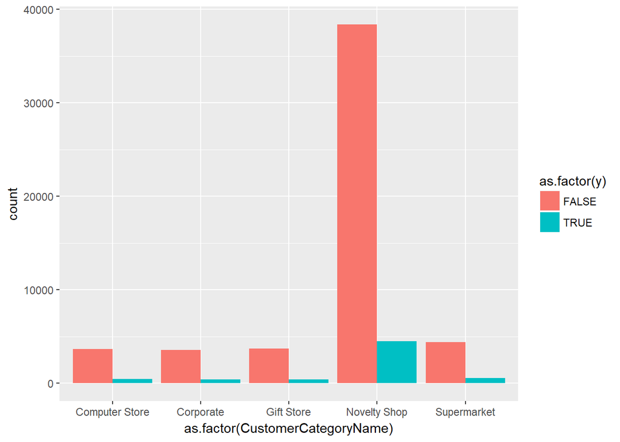

```r
ggplot(train, aes(as.factor(CustomerCategoryName), fill=as.factor(y))) +
  geom_bar(position='dodge')
```

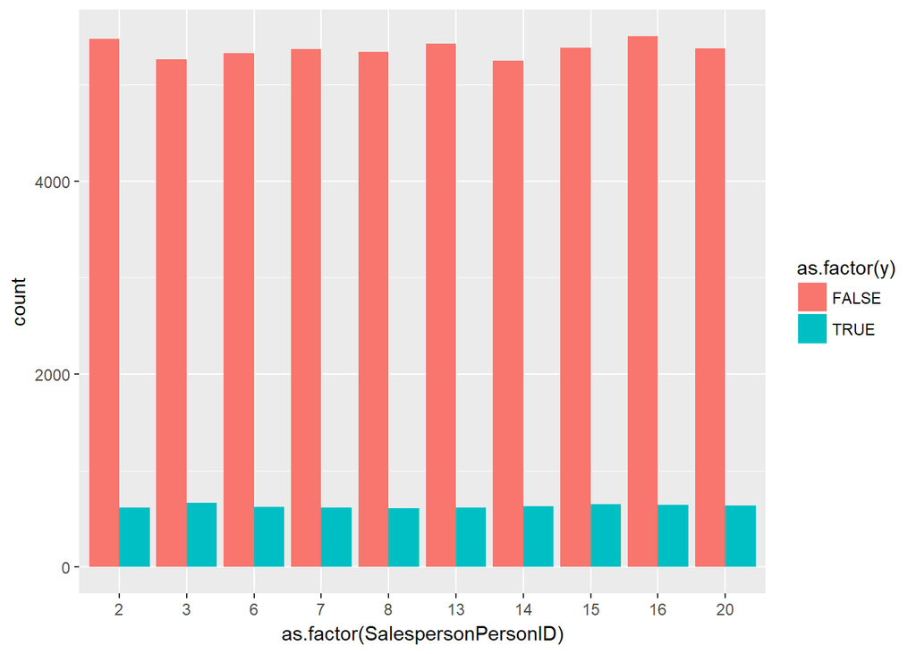

```r
ggplot(train, aes(as.factor(SalespersonPersonID), fill=as.factor(y))) +
  geom_bar(position='dodge')
```

```r
library(MASS)

glm1 <- glm(y ~ as.factor(order_year) +  as.factor(SalespersonPersonID) +
            as.factor(order_month)  + as.factor(CustomerCategoryID) +
            as.factor(order_wk) +
          + as.factor(StateProvinceID),
         data=train, family='binomial')

anova(glm1, test='LRT')
```

```
## Analysis of Deviance Table
##
## Model: binomial, link: logit
##
## Response: y
##
## Terms added sequentially (first to last)
##
##
##                                Df Deviance Resid. Df Resid. Dev Pr(>Chi)
## NULL                                           59999      40333
## as.factor(order_year)           3    0.256     59996      40333   0.9681
## as.factor(SalespersonPersonID)  9    5.924     59987      40327   0.7475
## as.factor(order_month)         11   11.152     59976      40316   0.4306
## as.factor(CustomerCategoryID)   4    1.066     59972      40315   0.8996
## as.factor(order_wk)            52   50.462     59920      40264   0.5345
## as.factor(StateProvinceID)     48   45.108     59872      40219   0.5921
```